# Practico 1 – ModEst

Gaston Rijo

4/22/2021

## Introducción

El objetivo de este práctico es obtener mínimos conocimientos sobre la sintaxis de R, en especial el manejo de matrices, vectores y sus operaciones.

## Funciones

Las funciones de R son objetos que aceptan como *argumentos* otros objetos. La sintaxis es de la forma `funcion(x,y,z,...)` donde `funcion` indica el nombre de la función, y los paréntesis delimitan los argumentos, separados por comas. Distintas funciones van a requerir distintos argumentos. Hay funciones que no requieren argumentos, hay funciones que requieren un número fijo de argumentos, y funciones que pueden aceptar argumentos opcionales.

R y sus paquetes básicos vienen con un montón de funciones. Para obtener ayuda sobre una función y sus argumentos, podés escribir `?funcion` en la consola para invocar la ayuda.

Más adelante veremos como crear funciones propias.

## Vectores

Los vectores en R pueden ser objetos de distintos tipos:

- `numeric` (como se imaginarán, números)
- `character` (caracteres alfanumericos)
- `logical` (numeros booleanos, verdaeros y falsos)

Si queremos crear vectores, lo hacemos usando la función `c()`:

```r
v_numerico <- c(1,2,3,4)
v_caracter <- c("a","b","c","d")
v_logico <- c(T,F,F,T)
```

Podemos visualizar su contenido escribiendo el nombre de la variable:

```r
v_numerico
```

```
## [1] 1 2 3 4
```

```r
v_caracter
```

```
## [1] "a" "b" "c" "d"
```

```r
v_logico
```

```
## [1]  TRUE FALSE FALSE  TRUE
```

Y podemos verificar que son del tipo (clase) adecuado usando la función `class()`:

```r
class(v_numerico)
```

```
## [1] "numeric"
```

```r
class(v_caracter)
```

```
## [1] "character"
```

```r
class(v_logico)
```

```
## [1] "logical"
```

A partir de ahora, seguiremos trabajando únicamente con un vector numérico, pero todo lo que veremos seguirá aplicando para los otros tipos de vectores. Nuestro nuevo vector contenido en la variable `v` es

```r
v <- c(10,11,12,13,14,15,16,17,18)
v
```

```
## [1] 10 11 12 13 14 15 16 17 18
```

Habrá alguna manera de hacer esto mas fácil? Sin estar escribiendo numero, coma, numero, etc. Sí la hay. Podemos obtener el mismo vector usando la función `seq()`.

```r
v <- seq(10,18)
v
```

```
## [1] 10 11 12 13 14 15 16 17 18
```

En principio es bastante útil conceptualizar los vectores en R tal cual lo haríamos en álgebra lineal. Es posible acceder a entradas particulares de vectores usando el operador `[·]`:

```r
v[2]
```

```
## [1] 11
```

Además, podemos obtener subsecciones de las entradas de los vectores usando también el operador `:`:

```r
v[3:6]
```

```
## [1] 12 13 14 15
```

Muchas funciones son aplicables a vectores, es decir, funciones vectorizadas. Veremos algunas de las mas comunes:

```r
sum(v)
```

```
## [1] 126
```

```r
mean(v)
```

```
## [1] 14
```

```r
sd(v)
```

```
## [1] 2.738613
```

### Ejercicios

1. Explora las opciones de las funciones `seq()` , `rep()` y `length()`
2. Calcula la media de un vector sin usar la función `mean()`

## Matrices

Rápidamente pasamos al uso de matrices en R. En principio, una matriz la podemos definir a partir de un vector. En este caso partimos de nuestro vector contenido en `v`:

```r
m <- matrix(v)
m
```

```
##       [,1]
##  [1,]   10
##  [2,]   11
##  [3,]   12
##  [4,]   13
##  [5,]   14
##  [6,]   15
##  [7,]   16
##  [8,]   17
##  [9,]   18
```

```r
class(m)
```

```
## [1] "matrix" "array"
```

No es como pensaríamos que se vería una matriz no? Bueno, en principio los vectores son matrices de una columna (o fila). El comportamiento por defecto de `matrix()` transforma un vector en un objeto de tipo matriz con sus dimensiones correspondientes. Si queremos obtener una matriz $3 \times 3$ por ejemplo, es necesario darle algunos argumentos adicionales.

```r
m <- matrix(v, ncol = 3)
m
```

```
##      [,1] [,2] [,3]
## [1,]   10   13   16
## [2,]   11   14   17
## [3,]   12   15   18
```

Si especificamos el numero de columnas (o de filas), vemos que la forma de la matriz queda determinada. Por defecto `matrix()` va llenando los lugares de la nueva matriz por columnas. Si queremos que se llenen por filas:

```r
m <- matrix(v, ncol = 3, byrow = TRUE)
m
```

```
##      [,1] [,2] [,3]
## [1,]   10   11   12
## [2,]   13   14   15
## [3,]   16   17   18
```

Usamos el operador `[]` para acceder a los elementos de una matriz:

```r
m[1,1]
```

```
## [1] 10
```

```r
m[2,3]
```

```
## [1] 15
```

```r
m[2,] # que hace esto?
```

```
## [1] 13 14 15
```

```r
m[,3] # y esto?
```

```
## [1] 12 15 18
```

Podemos aplicar varios de los operadores básicos de álgebra lineal a matrices en R con sus correspondientes funciones:

```r
det(m)
```

```
## [1] 0
```

Hm, no sirve para los ejemplos que el determinante sea 0. ¿Por qué? Vamos a definir medio rápido una nueva matriz cuyo determinante no sea 0. Ojo que no voy a explicar como, solo lo muestro.

```r
set.seed(2021)
m <- matrix(
    round(runif(9)*10), nrow = 3
)
m
```

```
##      [,1] [,2] [,3]
## [1,]    5    4    6
## [2,]    8    6    3
## [3,]    7    7    8
```

Ahora si:

```r
det(m) # determinante
```

```
## [1] 47
```

```r
t(m) # transpuesta
```

```
##      [,1] [,2] [,3]
## [1,]    5    8    7
## [2,]    4    6    7
## [3,]    6    3    8
```

```r
solve(m) # inversa
```

```
##            [,1]        [,2]        [,3]
## [1,]  0.5744681  0.21276596 -0.51063830
## [2,] -0.9148936 -0.04255319  0.70212766
## [3,]  0.2978723 -0.14893617 -0.04255319
```

```r
diag(m) # elementos de la diagonal
```

```
## [1] 5 6 8
```

Pueden encontrar mas información [aqui](https://www.statmethods.net/advstats/matrix.html).

### Operaciones matriciales

Si queremos saber como hacer un PCA *de cero*, tenemos que saber como se usan las operaciones matriciales básicas en R. Definamos un vector y una matriz como ejemplos.

```r
v <- c(1,1)
m <- matrix(
    c(-1,0,0,1), ncol = 2
)
```

Primero, graficamos el vector en coordenadas cartesianas:

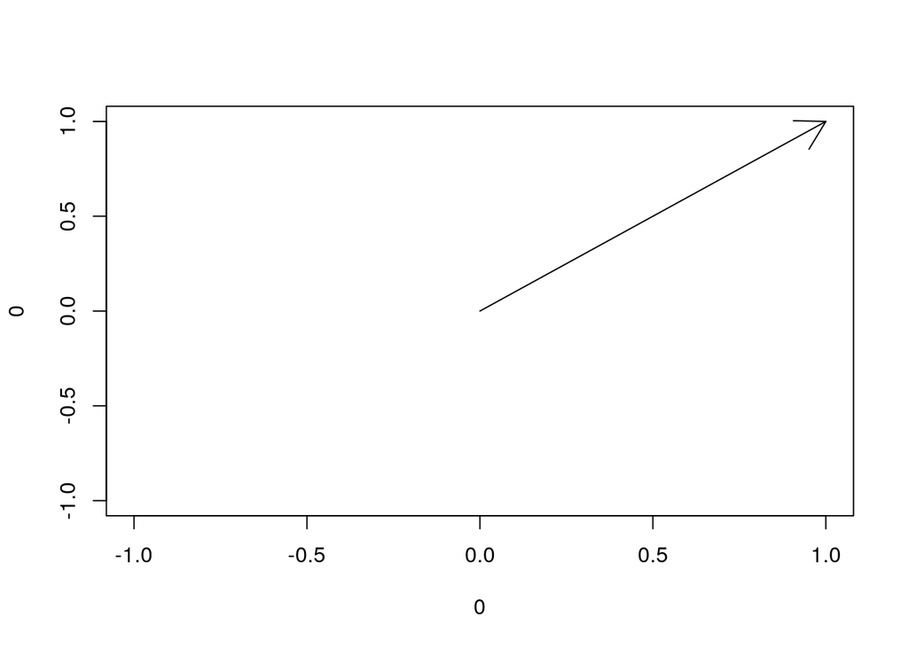

```r
plot(0,0, cex=0)
arrows(0,0,v[1],v[2])
```

La suma y resta de vectores y matrices es bastante directa, siguiendo las mismas reglas y sintaxis que el algebra lineal:

```r
w <- v - c(0.5,0)
w
```

```
## [1] 0.5 1.0
```

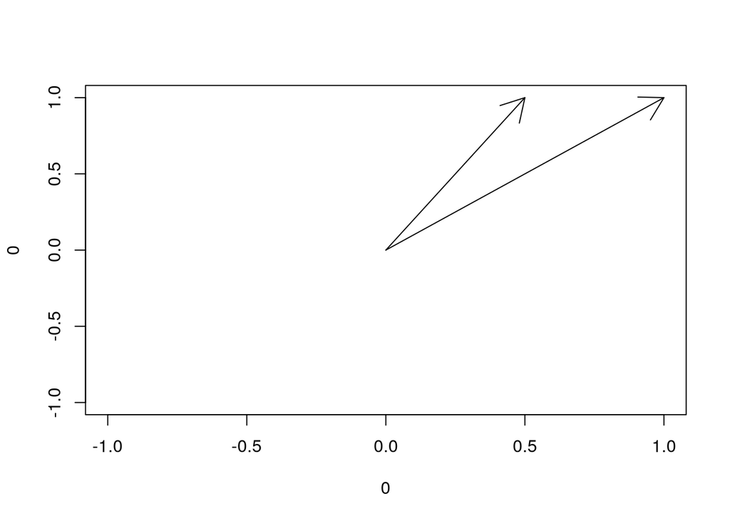

```r
plot(0,0, cex=0)
arrows(0,0,v[1],v[2])
arrows(0,0,w[1],w[2])
```

Si queremos multiplicar un vector por un escalar, solo basta con:

```r
w <- v * -2
w
```

```
## [1] -2 -2
```

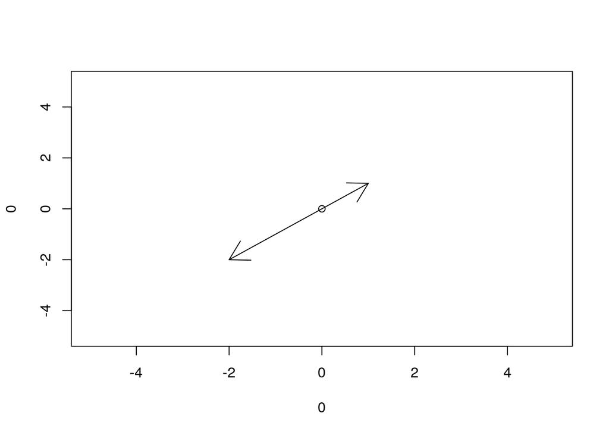

```r
plot(0,0, ylim=c(-5,5), xlim=c(-5,5))
arrows(0,0,v[1],v[2])
arrows(0,0,w[1],w[2])
```

Ahora, si queremos realizar multiplicaciones matriciales necesitamos usar el operador `%*%`.

```r
w %*% v # es el producto interno
```

```
##      [,1]
## [1,]   -4
```

```r
matrix(w) %*% t( matrix(v) ) # para computar el producto externo (Que hace cada paso?)
```

```
##      [,1] [,2]
## [1,]   -2   -2
## [2,]   -2   -2
```

Volviendo a las matrices, podemos realizar el producto matricial entre nuestros vectores y la matriz previamente definida.

```r
v
```

```
## [1] 1 1
```

```r
m
```

```
##      [,1] [,2]
## [1,]   -1    0
## [2,]    0    1
```

```r
w <-  m %*% matrix(v)
w
```

```
##      [,1]
## [1,]   -1
## [2,]    1
```

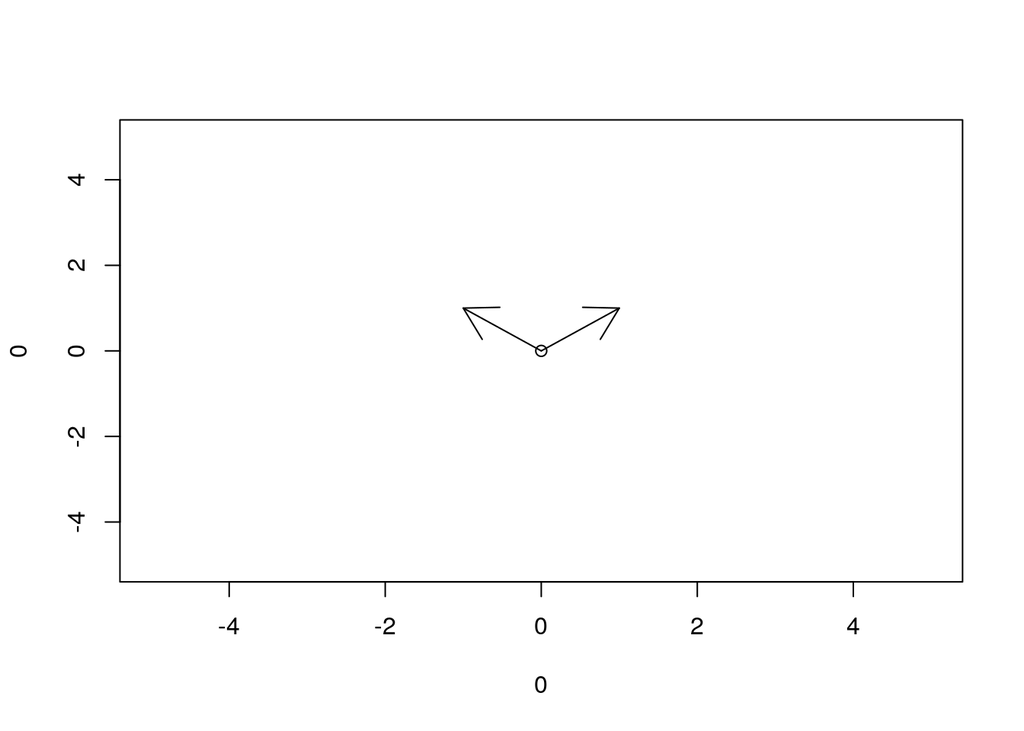

```r
plot(0,0, ylim=c(-5,5), xlim=c(-5,5))
arrows(0,0,v[1],v[2])
arrows(0,0,w[1],w[2])
```

En cuanto al producto de matrices, es importante resaltar la diferencia entre los operadores `*` y `%*%`:

```r
set.seed(2021)
m <- matrix(
    round(runif(9)*10), nrow = 3
)
m
```

```
##      [,1] [,2] [,3]
## [1,]    5    4    6
## [2,]    8    6    3
## [3,]    7    7    8
```

```r
m * m  # multiplicacion elemento-por-elemento
```

```
##      [,1] [,2] [,3]
## [1,]   25   16   36
## [2,]   64   36    9
## [3,]   49   49   64
```

```r
m%*%m # multiplicacion matricial
```

```
##      [,1] [,2] [,3]
## [1,]   99   86   90
## [2,]  109   89   90
## [3,]  147  126  127
```

### Ejercicios

1. Obtén una matriz de $2\times2$ multiplicando dos matrices de $4\times2$ y $2\times4$
2. Dibuja un vector y aplícale una transformación matricial de rotación. Dibuja el vector resultante.
3. Dibuja un vector y aplícale una transformación matricial de escalado. Dibuja el vector resultante.
4. Busca en internet cómo tomar la $n$ potencia de una matriz, y compútala.
5. Busca en internet cómo encontrar los vectores y valores propios de una matriz y compútalos.
6. Explora la documentación las funciones `cbind()` y `rbind()`. Construye una matriz a partir de varios vectores con estas funciones.

## Data frames

Los data frames son la clase de objeto mas conveniente para almacenar datos de todo tipo. Los vectores y matrices están restringidos a almacenar un solo tipo de dato, sea numérico, caracter o lógico. Los data frames, en cambio, pueden almacenar varios de estos datos.

La forma mas simple de inicializar un data frame es a partir de una matriz. Aunque, cotidianamente, leerìamos los datos desde un archivo de texto.

```r
set.seed(2021)
m <- matrix(
    round(runif(9)*10), nrow = 3
)
m
```

```
##      [,1] [,2] [,3]
## [1,]    5    4    6
## [2,]    8    6    3
## [3,]    7    7    8
```

```r
d <- as.data.frame(m)
d
```

```
##   V1 V2 V3
## 1  5  4  6
## 2  8  6  3
## 3  7  7  8
```

Los dataframes necesariamente tienen que tener nombres de columnas. Como no los proveímos al inicializarla, fueron generados automáticamente. A continuación, agregaremos una nueva columna que contenga un vector de caracteres.

```r
d["char"] = c("a","b","c")
```

Definimos `d` de nuevo.

```r
set.seed(2021)
m <- matrix(
    round(runif(9)*10), nrow = 3
)
m
```

```
##      [,1] [,2] [,3]
## [1,]    5    4    6
## [2,]    8    6    3
## [3,]    7    7    8
```

```r
d <- as.data.frame(m)
d
```

```
##   V1 V2 V3
## 1  5  4  6
## 2  8  6  3
## 3  7  7  8
```

Que pasa si aplicamos operadores como `sum()` a un dataframe?

```r
sum(d)
```

```
## [1] 54
```

```r
apply(d,FUN=sum, MARGIN = 1)
```

```
## [1] 15 17 22
```

### Ejercicios

1. Calcula la suma de todas las filas como en el ejemplo anterior.
2. Crea un dataframe de $4\times10$ y calcula su media y desviación estándar para cada columna.
3. Ponele nombres a las columnas de el dataframe anterior usando la función `colnames()`
4. Crea un dataframe con datos mixtos (columnas de distintos tipos). Luego separa el dataframe en dataframes de columnas del mismo tipo.
5. ¿Para que sirve el operador `$`?
6. Lee [aquí](https://www.guru99.com/r-apply-sapply-tapply.html) sobre las funciones de la familia `apply`. ¿En qué se diferencian una de otra?